# Environmental Plotting System

Package Development Team

2026-11-23

# Introduction

The plotting module provides a unified suite of visualization functions for environmental monitoring datasets.

All plotting functions support both raw data frames and `env_schema` objects through S3 method dispatch. The system is designed to operate independently of source column names by relying on schema mappings and accessor functions.

Supported visualizations include:

- Time-series plots
- Boxplots
- Correlation plots
- Piper diagrams
- Schoeller diagrams
- Stiff diagrams
- Durov diagrams
- Spatial plots
- Geochemical animations

# Design Philosophy

## Schema-Aware Architecture

All environmental plotting functions ultimately operate on an `env_schema` object.

When a raw data frame is supplied, it is first converted using user-provided column mappings.

For example:

```r
series_plot(
  groundwater_data,
  location = well_id,
  sample_date = sample_date,
  analyte = constituent,
  result = concentration
)
```

internally becomes:

```r
env_schema(
  groundwater_data,
  location = well_id,
  sample_date = sample_date,
  analyte = constituent,
  result = concentration
)
```

Internally, plotting methods interact with schema accessors rather than hard-coded column names:

```r
location_var()
sample_date_var()
analyte_var()
analysis_result_var()
analysis_unit_var()
reporting_flag_var()
```

This architecture ensures plots remain portable across different environmental datasets.

# Example Datasets

The package includes groundwater monitoring datasets that can be used to demonstrate plotting functionality.

## Standardized Example Dataset

The `gw` dataset is an `env_schema` object and can be used directly with plotting functions.

```r
library(dplyr)
library(manager)

data(gw)

gw
```

```
#> # A tibble: 5,878 × 45
#>    location_id param_name       sample_date         analysis_result default_unit
#>  * <chr>       <chr>            <dttm>                        <dbl> <chr>
#>  1 MW-2        Magnesium, diss… 2008-10-28 00:00:00           36.3  mg/L
#>  2 MW-2        Sodium, dissolv… 2008-10-28 00:00:00           18.9  mg/L
#>  3 MW-2        Potassium, diss… 2008-10-28 00:00:00            0.5  mg/L
#>  4 MW-2        Chloride, total  2008-10-28 00:00:00           24.9  mg/L
#>  5 MW-2        Sulfate, total   2008-10-28 00:00:00          170    mg/L
#>  6 MW-2        Fluoride, total  2008-10-28 00:00:00            0.29 mg/L
#>  7 MW-2        Arsenic, dissol… 2008-10-28 00:00:00            1.9  ug/L
#>  8 MW-2        Barium, dissolv… 2008-10-28 00:00:00          107    ug/L
#>  9 MW-2        Beryllium, diss… 2008-10-28 00:00:00            0.5  ug/L
#> 10 MW-2        Boron, dissolved 2008-10-28 00:00:00            2.34 mg/L
#> # ℹ 5,868 more rows
#> # ℹ 40 more variables: lt_measure <chr>, .analysis_result <dbl>,
#> #   .analysis_unit <chr>, .censored <lgl>, .source_analyte <chr>,
#> #   .normalized_input <chr>, .analyte <chr>, .analyte_id <chr>,
#> #   .normalized_analyte <chr>, .fraction <chr>, .is_known_analyte <lgl>,
#> #   .result_type <chr>, .detected <lgl>, .estimated <lgl>, .rejected <lgl>,
#> #   .usable <lgl>, .original_lab_result <dbl>, .analysis_method <chr>, …
```

Because `gw` is already an `env_schema`, no additional mapping is required.

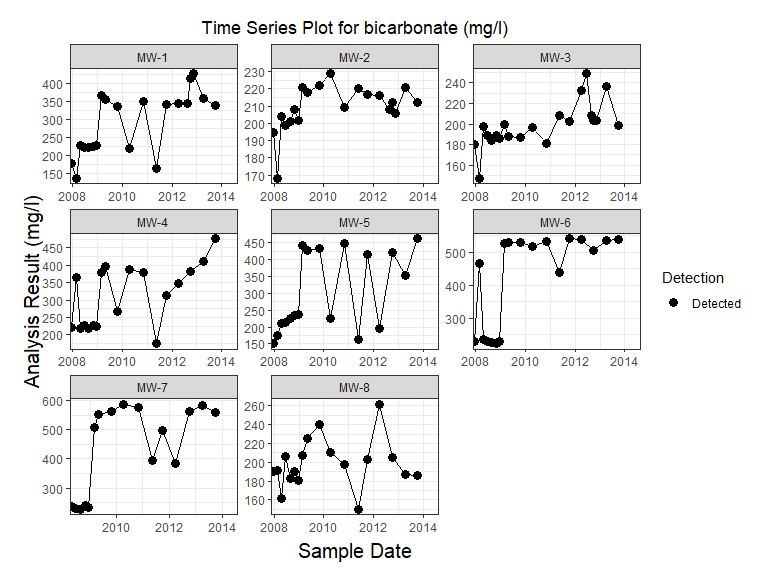

```r
plots <- series_plot(gw)

plots[[1]]
```

## Raw Groundwater Dataset

The `gw_data` dataset contains environmental monitoring data in tabular format.

```r
data(gw_data)

glimpse(gw_data)
```

```
#> Rows: 5,878
#> Columns: 6
#> $ location_id     <chr> "MW-2", "MW-2", "MW-2", "MW-2", "MW-2", "MW-2", "MW-2"…
#> $ sample_date     <dttm> 2008-10-28, 2008-10-28, 2008-10-28, 2008-10-28, 2008-…
#> $ analysis_result <dbl> 36.300, 18.900, 0.500, 24.900, 170.000, 0.290, 1.900, …
#> $ lt_measure      <chr> NA, NA, NA, NA, NA, NA, NA, NA, "<", NA, "<", "<", NA,…
#> $ default_unit    <chr> "mg/L", "mg/L", "mg/L", "mg/L", "mg/L", "mg/L", "ug/L"…
#> $ param_name      <chr> "Magnesium, dissolved", "Sodium, dissolved", "Potassiu…
```

Create a smaller subset for examples.

```r
example_wells <- c(
  "MW-1",
  "MW-2",
  "MW-3"
)

gw_subset <- gw_data %>%
  dplyr::filter(
    location_id %in% example_wells
  )
```

## Creating an env_schema Object

Raw datasets can be converted into an `env_schema` object.

```r
gw_schema <- env_schema(
  gw_subset,
  location = location_id,
  sample_date = sample_date,
  analyte = param_name,
  result = analysis_result,
  unit = default_unit,
  reporting_flag = lt_measure
)

gw_schema
```

```
#> # A tibble: 2,372 × 45
#>    location_id param_name       sample_date         analysis_result default_unit
#>  * <chr>       <chr>            <dttm>                        <dbl> <chr>
#>  1 MW-2        Magnesium, diss… 2008-10-28 00:00:00           36.3  mg/L
#>  2 MW-2        Sodium, dissolv… 2008-10-28 00:00:00           18.9  mg/L
#>  3 MW-2        Potassium, diss… 2008-10-28 00:00:00            0.5  mg/L
#>  4 MW-2        Chloride, total  2008-10-28 00:00:00           24.9  mg/L
#>  5 MW-2        Sulfate, total   2008-10-28 00:00:00          170    mg/L
#>  6 MW-2        Fluoride, total  2008-10-28 00:00:00            0.29 mg/L
#>  7 MW-2        Arsenic, dissol… 2008-10-28 00:00:00            1.9  ug/L
#>  8 MW-2        Barium, dissolv… 2008-10-28 00:00:00          107    ug/L
#>  9 MW-2        Beryllium, diss… 2008-10-28 00:00:00            0.5  ug/L
#> 10 MW-2        Boron, dissolved 2008-10-28 00:00:00            2.34 mg/L
#> # ℹ 2,362 more rows
#> # ℹ 40 more variables: lt_measure <chr>, .analysis_result <dbl>,
#> #   .analysis_unit <chr>, .censored <lgl>, .source_analyte <chr>,
#> #   .normalized_input <chr>, .analyte <chr>, .analyte_id <chr>,
#> #   .normalized_analyte <chr>, .fraction <chr>, .is_known_analyte <lgl>,
#> #   .result_type <chr>, .detected <lgl>, .estimated <lgl>, .rejected <lgl>,
#> #   .usable <lgl>, .original_lab_result <dbl>, .analysis_method <chr>, …
```

# Time Series Plots

## Basic Example

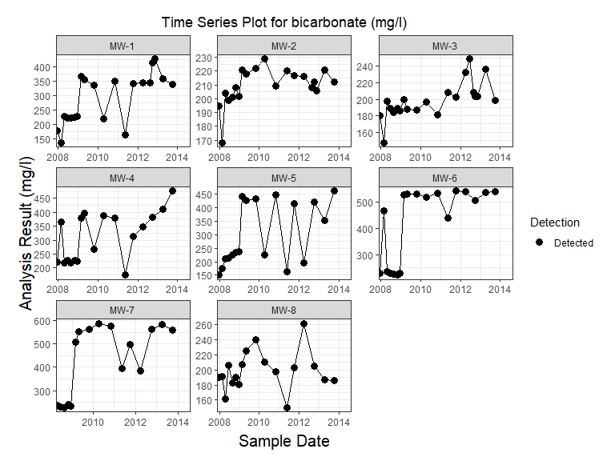

```r
plots <- series_plot(gw)

plots[[1]]
```

## Linear Trend

Linear regression is demonstrated using detected results only. Censored observations require a censored-aware trend method such as Mann-Kendall with cenken.

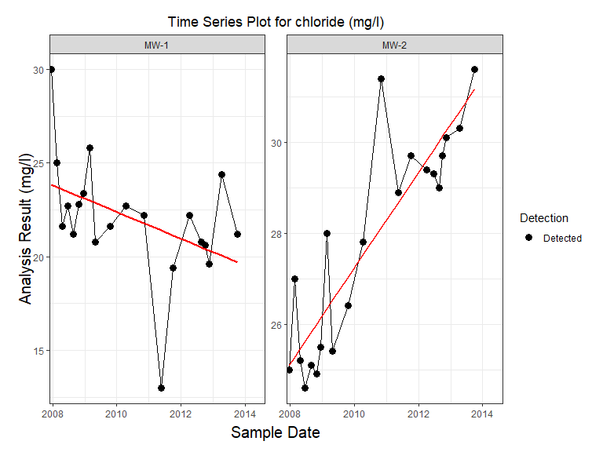

```r
lm_trend_data <- gw |>
  filter(location_id %in% c("MW-1", "MW-2"),
         param_name %in% c(
           "Chloride, total",
           "Sulfate, total"
         )
        )

plots <- series_plot(
  lm_trend_data,
  trend = "lm"
)

plots[[1]]
```

## Mann-Kendall Trend

```r
plots <- series_plot(
  gw,
  trend = "mann_kendall",
  trend_label = "compact"
)

plots[[1]]
```

## Combined Plot

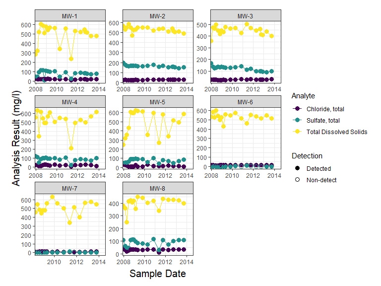

```r
gw |>
  filter(param_name %in% c("Chloride, total", "Sulfate, total", "Total Dissolved Solids")) |>
  series_plot(
    plot_type = "combined"
    )
```

## Standards Overlay

```
#> $`Arsenic, dissolved`
```

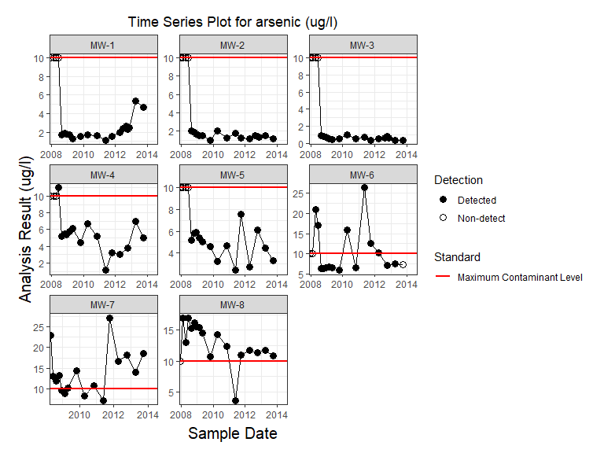

```r
gw |>
  filter(param_name == "Arsenic, dissolved") |>
  series_plot(
    standards = TRUE
    )
```

# Boxplots

## Basic Boxplot

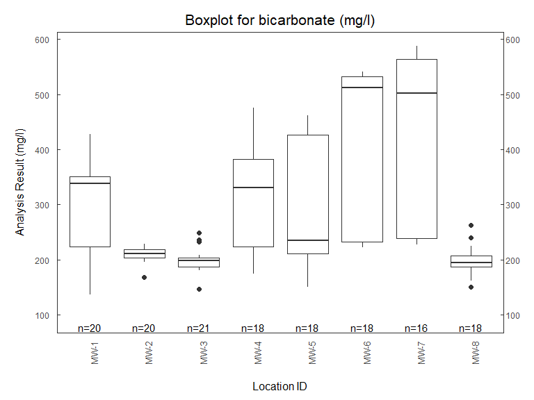

```r
plots <- boxplot(gw)

plots[[1]]
```

## Display Individual Observations

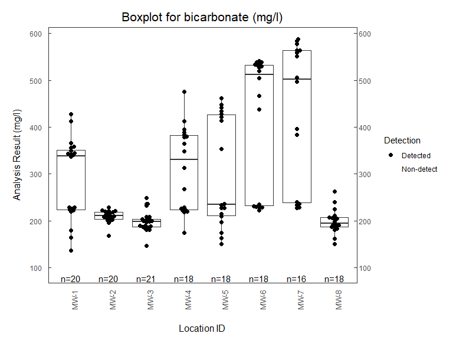

```r
plots <- boxplot(
  gw,
  show_points = TRUE
)

plots[[1]]
```

## Bootstrap Confidence Intervals

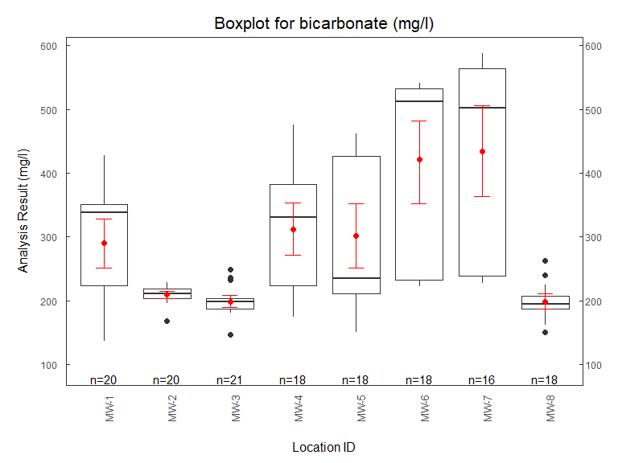

```r
plots <- boxplot(
  gw,
  show_points = FALSE,
  plot_ci = TRUE
)

plots[[1]]
```

## Standards Overlay

```
#> $`Arsenic, dissolved`
```

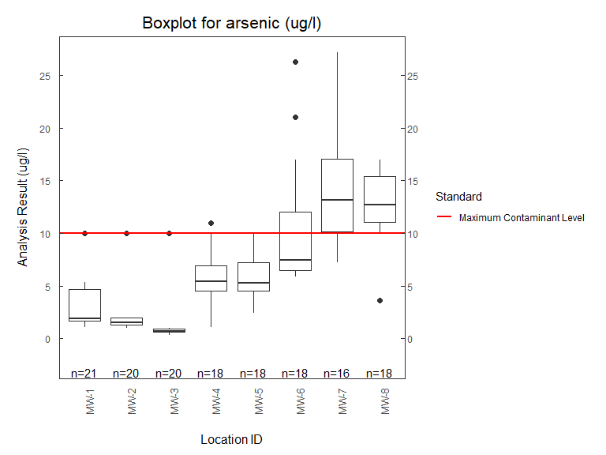

```r
gw |>
  filter(param_name == "Arsenic, dissolved") |>
  boxplot(
    standards = TRUE
    )
```

## Add Explanation Panel

```
#> $`Arsenic, dissolved`
```

[figure not shown]

```r
gw |>
  filter(param_name == "Arsenic, dissolved") |>
  boxplot(
    standards = TRUE,
    add_explanation = TRUE
    )
```

# Correlation Plots

Correlation plots require the optional `GGally` package.

```r
gw |>
  corr_plot(
  constituents = c(
    "Iron, dissolved",
    "Manganese, dissolved",
    "Sulfate, total"
  ),
  sample_locations = c(
    "MW-1",
    "MW-2"
  )
)
```

# Piper Diagrams

## Basic Piper Diagram

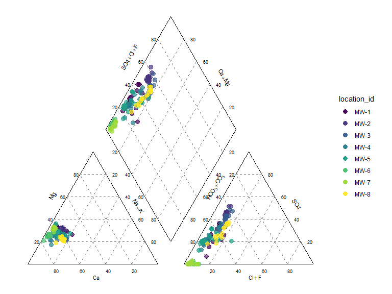

```r
piper_plot(gw)
```

## Scale Point Size by TDS

```r
piper_plot(
  gw,
  scale_analyte = "Total Dissolved Solids"
)
```

## Group by Category

```r
gw |>
  mutate(
    aquifer_unit = case_when(
      location_id %in% c("MW-1", "MW-2", "MW-3") ~ "Sand",
      location_id %in% c("MW-4", "MW-5") ~ "Shale",
      .default = "Limestone"
    )
  ) |>
  piper_plot(
    group_col = "aquifer_unit"
    )
```

# Piper Animations

Create an interactive animation:

```r
piper_time_plot(gw)
```

Export animation:

```r
piper_time_html(gw)
```

# Schoeller Diagrams

## Basic Schoeller Plot

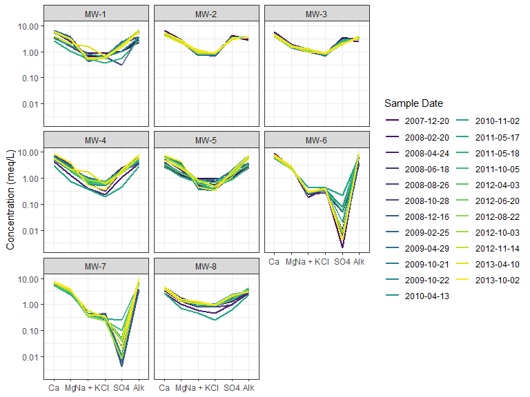

```r
schoeller_plot(gw)
```

## Facet by Location

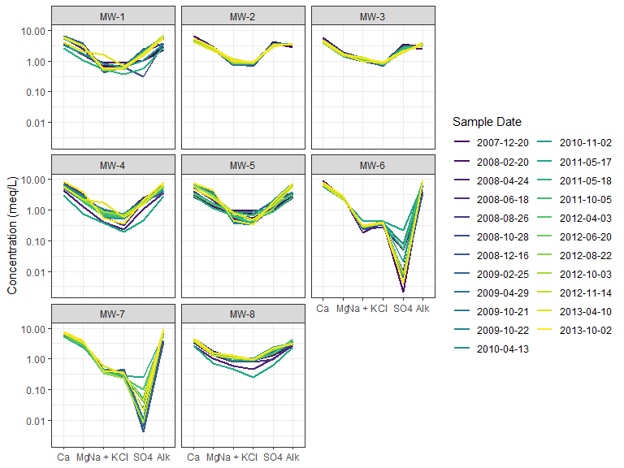

```r
schoeller_plot(
  gw,
  facet_var = location_var(gw)
)
```

## Facet by Date

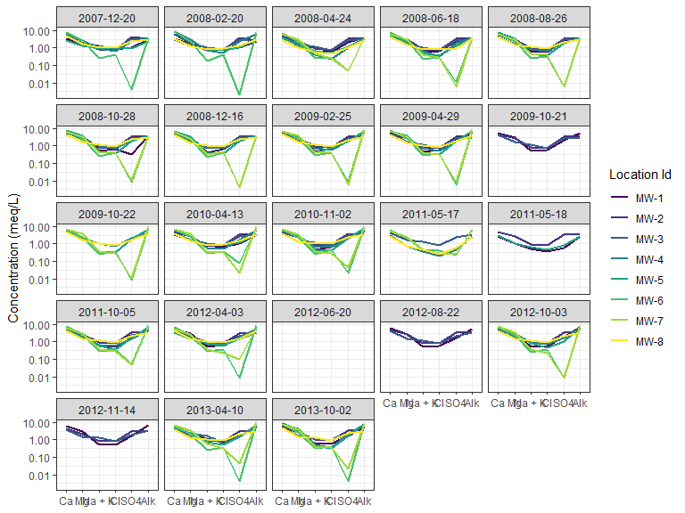

```r
schoeller_plot(
  gw,
  facet_var = sample_date_var(gw)
)
```

## Custom Title

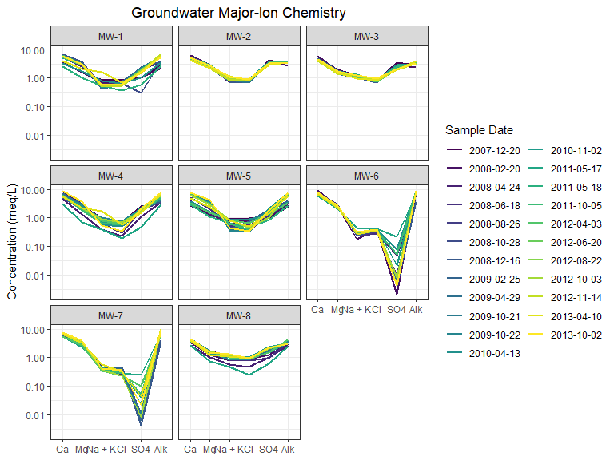

```r
schoeller_plot(
  gw,
  title = "Groundwater Major-Ion Chemistry"
)
```

# Stiff Diagrams

## Basic Stiff Diagram

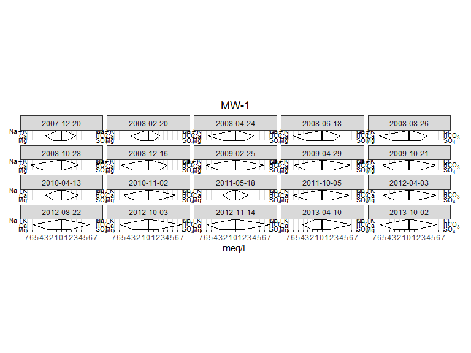

```r
plots <- stiff_plot(gw)

plots[[1]]
```

## Scale Fill by TDS

```r
plots <- stiff_plot(
  gw,
  scale_analyte = "Total Dissolved Solids"
)

plots[[1]]
```

## Add Reference Lines

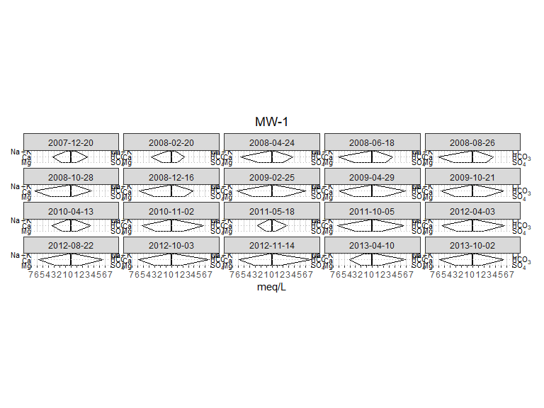

```r
plots <- stiff_plot(
  gw,
  lines = TRUE
)

plots[[1]]
```

# Stiff Diagram Animations

Interactive display:

```r
stiff_time_plot(gw)
```

HTML export:

```r
stiff_time_html(gw)
```

# Durov Diagrams

## Basic Durov Diagram

```r
durov_plot(gw)
```

## Normalized Matching

```r
durov_plot(
  gw,
  analyte_matching = "normalized"
)
```

## Exact Matching

```r
durov_plot(
  gw,
  analyte_matching = "exact"
)
```

# Regulatory Standards

Several plotting functions support standards overlays.

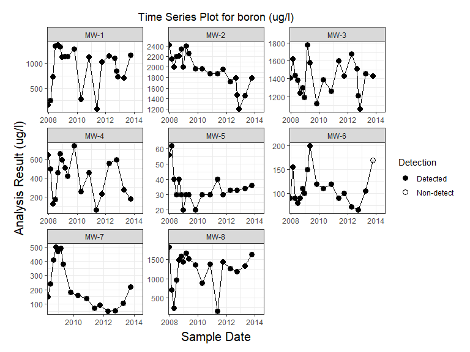

```r
plots <- series_plot(
  gw,
  standards = TRUE
)

plots[[7]]
```

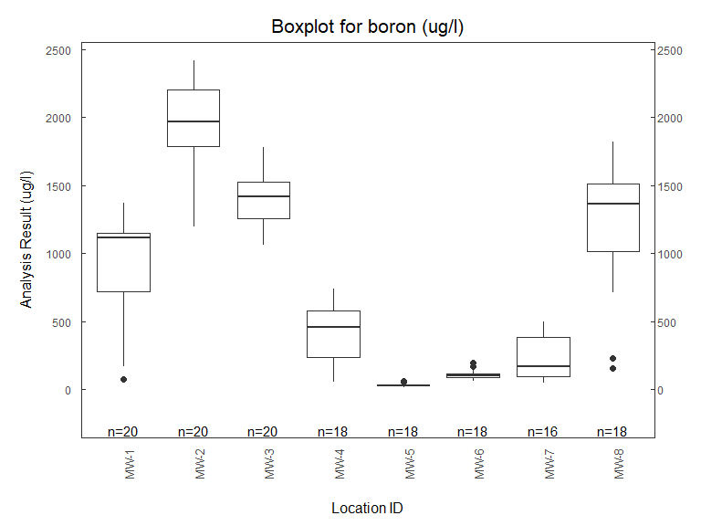

```r
plots <- boxplot(
  gw,
  standards = TRUE
)

plots[[7]]
```

# Animation Framework

The package includes shared animation helpers for geochemical plotting.

Animated workflows:

- `piper_time_plot()`
- `piper_time_html()`
- `stiff_time_plot()`
- `stiff_time_html()`

All animation utilities automatically determine the mapped date field from the schema metadata.

# Extending the Plotting Framework

New visualization functions should follow the same S3 design pattern used throughout the package.

## data.frame Method

```r
my_plot.data.frame <- function(
  df,
  location,
  sample_date,
  analyte,
  result,
  ...
) {

  df <- env_schema(
    df,
    location = {{ location }},
    sample_date = {{ sample_date }},
    analyte = {{ analyte }},
    result = {{ result }}
  )

  my_plot(df, ...)
}
```

## env_schema Method

```r
my_plot.env_schema <- function(
  df,
  ...
) {

  location_col <- location_var(df)

  sample_date_col <- sample_date_var(df)

  analyte_col <- analyte_var(df)

  result_col <- result_var(df)

  ...
}
```

Following this pattern ensures all future visualizations remain independent of source column names while remaining fully compatible with the package schema system.

# Summary

The environmental plotting framework provides:

- Schema-aware plotting
- Support for raw data frames and `env_schema` objects
- Consistent handling of analytical metadata
- Hydrochemical interpretation tools
- Animation support
- Extensible S3-based architecture

By leveraging schema accessors rather than hard-coded field names, plots remain portable, reusable, and robust across diverse environmental datasets.